# Tugas Inferensi

6181801015 - Gian Martin D.; 6181801044 - Yalvi Hidayat; 6181801077 - Bernadus Lukas

## Data

General Social Survey (GSS) adalah data yang diperoleh dari survey pada orang dewasa di Amerika Serikat sejak tahun 1972. Data diperoleh dari masyarakat kontemporer Amerika guna memonitor dan menjelaskan perubahan tren pada opini, sikap, dan perilaku masyarakat. Karena data diambil secara acak dari populasi, maka dapat dilakukan inferensi

[output not shown]

[output cut: 990 more lines]

```r
data <- load("gss.Rdata")
data <- data.frame(gss)
data
```

```
Error in gregexpr(calltext, singleline, fixed = TRUE) :
  regular expression is invalid UTF-8
```

```r
dataFinal <- na.omit(data)
dataFinal
```

| caseid | year | age | sex | race | hispanic | uscitzn | educ | paeduc | maeduc | speduc | degree | vetyears | sei | wrkstat | wrkslf | marital | spwrksta | sibs | childs | agekdbrn | incom16 | born | parborn | granborn | income06 | coninc | region | partyid | polviews | … |
| --- | --- | --- | --- | --- | --- | --- | --- | --- | --- | --- | --- | --- | --- | --- | --- | --- | --- | --- | --- | --- | --- | --- | --- | --- | --- | --- | --- | --- | --- | --- |

```r
na.omit(data$hispanic)
```

[output not shown]

[output cut: 272 more lines]

**Pertanyaan 1** Apakah ada perbedaan proporsi untuk dua status pernikahan (`marital`) (Married dan Divorced) berdasarkan dua kelompok jenis pekerjaan (`wrkstat`) (Fulltime dan Parttime) H0: Tidak ada perbedaan proporsi. Ha: Terdapat perbedaan proporsi.

##### Filter dataset berdasarkan `wrkstat` untuk “Working Fulltime” dan “Working Parttime”, dan `marital` untuk “Married” dan “Divorced”, lalu kelompokkan

```r
marital_wrkstat <- data %>%
  filter((marital == "Married" | marital == "Divorced") & (wrkstat == "Working Fulltime" | wrkstat == "Working Parttime")) %>%
  group_by(wrkstat, marital) %>%
  summarise(jumlah = n())

marital_wrkstat <- na.omit(marital_wrkstat)
marital_wrkstat
```

[figure not shown]

##### Lakukan prop test pada hasil pengelompokan

```r
prop.test(c(604, 4213), c(3005, 16027), correct = TRUE)
```

[output not shown]

**Pertanyaan 2** Apakah ada hubungan tingkat pendidikan (`degree`) dengan jumlah anak (`childs`) H0: Tidak ada hubungan antara keduanya Ha: Terdapat hubungan antara keduanya

##### Buat dataframe mengelompokan berdasarkan `degree` dan `childs` dan hitung jumlah masing-masing

```r
degree_childs <- data %>%
  group_by(degree, childs) %>%
  summarise(jumlah = n())

degree_childs <- na.omit(degree_childs)
degree_childs
```

##### Buat bar plot untuk melihat persebaran data

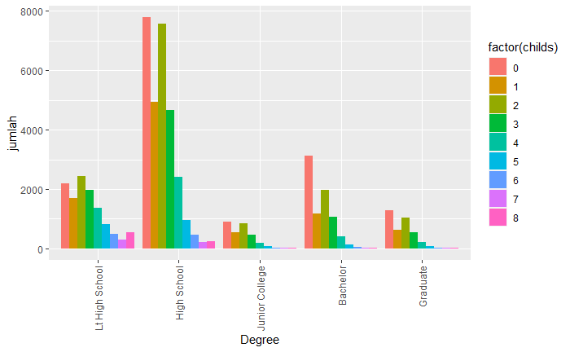

##### Lakukan uji chi squared untuk kolom `degree`dan `childs`

```r
chisq.test(data$degree, data$childs)
```

```
    Pearson's Chi-squared test

data:  data$degree and data$childs
X-squared = 3619.8, df = 32, p-value < 2.2e-16
```

Dari hasil uji chi square, diperoleh nilai p-value = 2.2e-16. Karena p-value lebih kecil dari 0.05 maka dapat ditolak H0-nya dan menerima Ha.

**Pertanyaan 3** Apakah ada hubungan antara ras (`race`) dan jumlah pendapatan (`income06`) H0: Terdapat hubungan antara ras dan pendapatan Ha: Tidak terdapat hubungan antara ras dan pendapatan

##### Kelompokan data berdasarkan `race` dan `income06` dan hitung jumlah masing-masing kelompok

```r
race_income06 <- data %>%
  group_by(race, income06) %>%
  summarise(jumlah = n())

race_income06 <- na.omit(race_income06)
race_income06
```

[figure not shown]

##### Lakukan uji chi squared untuk `race` dan `income06`

```r
chisq.test(data$race, data$income06)
```

[output not shown]